# DQR Overview

This notebook keeps only the core data understanding and data quality checks for `ppr-group-25208508-train.csv`. It performs baseline preprocessing and exploratory quality analysis to support downstream DQP decisions.

## 1) Imports

Load required libraries and set notebook display options. Core libraries: `pandas`, `numpy`, `matplotlib` (plus plotting/stat helpers used below).

```python
import pandas as pd
import numpy as np
```

## 2) Load Dataset

Load the training dataset: `ppr-group-25208508-train.csv`.

```python
file_path = '../ppr-group-25208508-train.csv'
df = pd.read_csv(file_path, encoding='utf-8')
```

```
Loaded: ../ppr-group-25208508-train.csv
Shape: (54000, 9)
```

|  | Date of Sale (dd/mm/yyyy) | Address | County | Eircode | Price (€) | Not Full Market Price | VAT Exclusive | Description of Property | Property Size Description |
| --- | --- | --- | --- | --- | --- | --- | --- | --- | --- |
| 0 | 30/09/2016 | 28 BRACKEN COURT, DONNYBROOK, CORK | Cork | NaN | €181,000.00 | No | No | Second-Hand Dwelling house /Apartment | NaN |
| 1 | 20/12/2016 | 2 AN CLOCHAR, CONVENT RD, DONERAILE | Cork | NaN | €50,152.49 | No | Yes | New Dwelling house /Apartment | less than 38 sq metres |
| 2 | 28/09/2016 | Apartment 7 The Court, Clonattin, Gorey | Wexford | NaN | €62,171.81 | No | Yes | New Dwelling house /Apartment | greater than or equal to 38 sq metres and less... |
| 3 | 16/09/2016 | 6 Monalin, Wicklow Hills, Newtownmountkennedy | Wicklow | NaN | €223,348.00 | No | Yes | New Dwelling house /Apartment | greater than or equal to 38 sq metres and less... |
| 4 | 29/01/2016 | 18 Lislea, Frascati Park, Blackrock | Dublin | NaN | €310,000.00 | No | No | Second-Hand Dwelling house /Apartment | NaN |

## 3) Basic Structure Check

This section summarizes dataset fundamentals:

- Data types (`df.dtypes`)
- Missing values per column
- Cardinality and top-frequency values

Purpose:

- Quickly identify high-missing features
- Detect high/low-cardinality fields
- Build evidence for cleaning and feature-engineering decisions

```python
print('Data types:')
```

```
Data types:
```

|  | dtype |
| --- | --- |
| Date of Sale (dd/mm/yyyy) | str |
| Address | str |
| County | str |
| Eircode | str |
| Price (€) | str |
| Not Full Market Price | str |
| VAT Exclusive | str |
| Description of Property | str |
| Property Size Description | str |

```
Missing values:
```

|  | missing_count |
| --- | --- |
| Property Size Description | 51164 |
| Eircode | 37108 |
| Date of Sale (dd/mm/yyyy) | 0 |
| Address | 0 |
| County | 0 |
| Price (€) | 0 |
| Not Full Market Price | 0 |
| VAT Exclusive | 0 |
| Description of Property | 0 |

```
Cardinality / Top 5 Frequency:
```

|  | feature | non_null_count | cardinality | top5_values | top5_counts | top5_freq_% |
| --- | --- | --- | --- | --- | --- | --- |
| 1 | Address | 54000 | 53261 | AUGHNASEDA, MONAGHAN \| ERREW, CASTLEHILL, BALL... | 5 \| 4 \| 3 \| 3 \| 3 | 0.01 \| 0.01 \| 0.01 \| 0.01 \| 0.01 |
| 3 | Eircode | 16892 | 16823 | D24W9NN \| F45FN32 \| D24YT67 \| H91DNF4 \| D02R658 | 4 \| 2 \| 2 \| 2 \| 2 | 0.02 \| 0.01 \| 0.01 \| 0.01 \| 0.01 |
| 4 | Price (€) | 54000 | 6845 | €150,000.00 \| €250,000.00 \| €200,000.00 \| €300... | 619 \| 596 \| 577 \| 492 \| 486 | 1.15 \| 1.1 \| 1.07 \| 0.91 \| 0.9 |
| 0 | Date of Sale (dd/mm/yyyy) | 54000 | 2487 | 18/12/2020 \| 21/12/2020 \| 22/12/2020 \| 20/12/2... | 107 \| 102 \| 97 \| 95 \| 89 | 0.2 \| 0.19 \| 0.18 \| 0.18 \| 0.16 |
| 2 | County | 54000 | 26 | Dublin \| Cork \| Kildare \| Galway \| Meath | 16592 \| 5975 \| 2926 \| 2600 \| 2325 | 30.73 \| 11.06 \| 5.42 \| 4.81 \| 4.31 |
| 8 | Property Size Description | 2836 | 4 | greater than or equal to 38 sq metres and less... | 2105 \| 507 \| 131 \| 93 | 74.22 \| 17.88 \| 4.62 \| 3.28 |
| 7 | Description of Property | 54000 | 3 | Second-Hand Dwelling house /Apartment \| New Dw... | 44332 \| 9665 \| 3 | 82.1 \| 17.9 \| 0.01 |
| 5 | Not Full Market Price | 54000 | 2 | No \| Yes | 51150 \| 2850 | 94.72 \| 5.28 |
| 6 | VAT Exclusive | 54000 | 2 | No \| Yes | 44486 \| 9514 | 82.38 \| 17.62 |

## 4) Cardinality Check

Cardinality analysis is used to identify features with too many unique values, which may cause sparse encoding, overfitting, or unnecessary complexity.

Main findings:

- `County`: Dublin is overrepresented (about one-third of samples); finer Dublin granularity is useful.
- `Address`: extremely high cardinality; not suitable as a raw modeling feature.
- `Eircode`: high cardinality with high missingness; low stability as a direct feature.
- `Property Size Description`: low usable information due to severe missingness.
- `Date of Sale (dd/mm/yyyy)`: decomposed into time features (year/month) instead of using raw high-cardinality dates.

```python
import numpy as np
import pandas as pd
```

|  | feature | dtype | non_null_count | missing_count | missing_% | cardinality | top_value | top_count | top_freq_% |
| --- | --- | --- | --- | --- | --- | --- | --- | --- | --- |
| 7 | Property Size Description | str | 2836 | 51164 | 94.75 | 4 | greater than or equal to 38 sq metres and less... | 2105 | 74.22 |
| 2 | Eircode | str | 16892 | 37108 | 68.72 | 16823 | D24W9NN | 4 | 0.02 |
| 0 | Address | str | 54000 | 0 | 0.00 | 53261 | AUGHNASEDA, MONAGHAN | 5 | 0.01 |
| 3 | Price (€) | str | 54000 | 0 | 0.00 | 6845 | €150,000.00 | 619 | 1.15 |
| 1 | County | str | 54000 | 0 | 0.00 | 26 | Dublin | 16592 | 30.73 |
| 6 | Description of Property | str | 54000 | 0 | 0.00 | 3 | Second-Hand Dwelling house /Apartment | 44332 | 82.10 |
| 4 | Not Full Market Price | str | 54000 | 0 | 0.00 | 2 | No | 51150 | 94.72 |
| 5 | VAT Exclusive | str | 54000 | 0 | 0.00 | 2 | No | 44486 | 82.38 |

```
=== Address | cardinality=53261 | non_null=54000 ===
```

|  | value | count | frequency_% |
| --- | --- | --- | --- |
| 0 | AUGHNASEDA, MONAGHAN | 5 | 0.01 |
| 1 | ERREW, CASTLEHILL, BALLINA | 4 | 0.01 |
| 2 | BRAMBLE COTTAGE, NEWMARKET ON FERGUS, CO CLARE | 3 | 0.01 |
| 3 | MAIN ST, STRADBALLY, LAOIS | 3 | 0.01 |
| 4 | 85 KILLEEN WOOD, TRALEE, KERRY | 3 | 0.01 |
| 5 | STRADBALLY EAST, CLARINBRIDGE, GALWAY | 3 | 0.01 |
| 6 | THE HATCHERY, HATCHERY LANE, INISTIOGE | 3 | 0.01 |
| 7 | 52 ROCKBARTON PARK, SALTHILL, GALWAY | 3 | 0.01 |
| 8 | MCCURTAIN ST, CLONES, MONAGHAN | 3 | 0.01 |
| 9 | FARRNASTACK, LISSELTON, CO KERRY | 3 | 0.01 |

```
=== County | cardinality=26 | non_null=54000 ===
```

|  | value | count | frequency_% |
| --- | --- | --- | --- |
| 0 | Dublin | 16592 | 30.73 |
| 1 | Cork | 5975 | 11.06 |
| 2 | Kildare | 2926 | 5.42 |
| 3 | Galway | 2600 | 4.81 |
| 4 | Meath | 2325 | 4.31 |
| 5 | Limerick | 2063 | 3.82 |
| 6 | Wicklow | 1924 | 3.56 |
| 7 | Wexford | 1883 | 3.49 |
| 8 | Tipperary | 1538 | 2.85 |
| 9 | Louth | 1534 | 2.84 |

```
=== Eircode | cardinality=16823 | non_null=16892 ===
```

|  | value | count | frequency_% |
| --- | --- | --- | --- |
| 0 | NaN | 37108 | 68.72 |
| 1 | D24W9NN | 4 | 0.01 |
| 2 | F45FN32 | 2 | 0.00 |
| 3 | D24YT67 | 2 | 0.00 |
| 4 | H91DNF4 | 2 | 0.00 |
| 5 | D02R658 | 2 | 0.00 |
| 6 | N39YR29 | 2 | 0.00 |
| 7 | D24H5YV | 2 | 0.00 |
| 8 | D09A0P0 | 2 | 0.00 |
| 9 | A82AE06 | 2 | 0.00 |

```
=== Price (€) | cardinality=6845 | non_null=54000 ===
```

|  | value | count | frequency_% |
| --- | --- | --- | --- |
| 0 | €150,000.00 | 619 | 1.15 |
| 1 | €250,000.00 | 596 | 1.10 |
| 2 | €200,000.00 | 577 | 1.07 |
| 3 | €300,000.00 | 492 | 0.91 |
| 4 | €100,000.00 | 486 | 0.90 |
| 5 | €180,000.00 | 458 | 0.85 |
| 6 | €220,000.00 | 456 | 0.84 |
| 7 | €190,000.00 | 450 | 0.83 |
| 8 | €120,000.00 | 431 | 0.80 |
| 9 | €275,000.00 | 429 | 0.79 |

```
=== Not Full Market Price | cardinality=2 | non_null=54000 ===
```

|  | value | count | frequency_% |
| --- | --- | --- | --- |
| 0 | No | 51150 | 94.72 |
| 1 | Yes | 2850 | 5.28 |

```
=== VAT Exclusive | cardinality=2 | non_null=54000 ===
```

|  | value | count | frequency_% |
| --- | --- | --- | --- |
| 0 | No | 44486 | 82.38 |
| 1 | Yes | 9514 | 17.62 |

```
=== Description of Property | cardinality=3 | non_null=54000 ===
```

|  | value | count | frequency_% |
| --- | --- | --- | --- |
| 0 | Second-Hand Dwelling house /Apartment | 44332 | 82.10 |
| 1 | New Dwelling house /Apartment | 9665 | 17.90 |
| 2 | Teach/Árasán Cónaithe Atháimhe | 3 | 0.01 |

```
=== Property Size Description | cardinality=4 | non_null=2836 ===
```

|  | value | count | frequency_% |
| --- | --- | --- | --- |
| 0 | NaN | 51164 | 94.75 |
| 1 | greater than or equal to 38 sq metres and less... | 2105 | 3.90 |
| 2 | greater than or equal to 125 sq metres | 507 | 0.94 |
| 3 | less than 38 sq metres | 131 | 0.24 |
| 4 | greater than 125 sq metres | 93 | 0.17 |

## 5) Data Type Preparation

Type conversion is applied for stable downstream analysis.

Note:

- `Address` and `Eircode` are temporarily kept as string features at this stage to allow feature engineering before final keep/drop decisions.

```python
# Date parsing
if 'Date of Sale (dd/mm/yyyy)' in df.columns:
```

```
Updated dtypes:
```

|  | dtype |
| --- | --- |
| Date of Sale (dd/mm/yyyy) | datetime64[us] |
| Address | str |
| County | category |
| Eircode | str |
| Price (€) | float64 |
| Not Full Market Price | category |
| VAT Exclusive | category |
| Description of Property | category |
| Property Size Description | category |
| Sale Year | category |
| Sale Month | category |

## 6) Duplicates and Constant Columns

Duplicate check rule: exact row duplication only.

Result:

- 9 fully duplicated rows (very small proportion of total samples).
- These rows are removed to avoid redundant signal in later analysis/modeling.

```python
duplicate_count = df.duplicated().sum()
print(f'Duplicate rows: {duplicate_count}')
```

```
Duplicate rows: 9
Removed duplicate rows: 9
New shape: (53991, 11)
Constant columns (0): []
Removing duplicate columns...
Duplicate column pairs: 0
[]
```

## 7) Price Quality Checks (Rules and Thresholds)

Observed price characteristics for `Price (€)`:

- Strong right-skew (long tail)
- Mean (`~340k`) > median (`~250k`), indicating high-end pull
- Very high dispersion (large standard deviation)
- Core market range is relatively concentrated around the interquartile region
- Extreme values exist on both low and high ends

Conclusion:

- Clamping/winsorization is required for robust downstream analysis.

```python
numeric_cols = df.select_dtypes(include=[np.number]).columns.tolist()
cat_cols = df.select_dtypes(exclude=[np.number]).columns.tolist()
```

```
Numeric columns: ['Price (€)']
Categorical/date columns: ['Date of Sale (dd/mm/yyyy)', 'Address', 'County', 'Eircode', 'Not Full Market Price', 'VAT Exclusive', 'Description of Property', 'Property Size Description', 'Sale Year', 'Sale Month']
Numeric summary:
```

|  | count | mean | std | min | 25% | 50% | 75% | max |
| --- | --- | --- | --- | --- | --- | --- | --- | --- |
| Price (€) | 53991.0 | 340673.920041 | 1.662268e+06 | 5250.0 | 157000.0 | 250000.0 | 365000.0 | 225000000.0 |

## 7.1) Price Clamping Standard Deviation Check

```python
# Price quality checks (reuse preprocessed price series)
col = 'Price (€)'
```

```
5% boundary:  60,000.00
95% boundary: 703,000.00
2% boundary:  37,500.00
98% boundary: 1,000,000.00
1% boundary:  27,000.00
99% boundary: 1,500,000.00
Upper bound: 677,000.00
Lower bound: -155,000.00
```

### 7.2) Original Price and 5%-95% Clamping

Apply percentile clamping on `Price (€)` (p05 to p95) as a robust baseline. This is used to stabilize exploratory analysis and support DQP decisions.

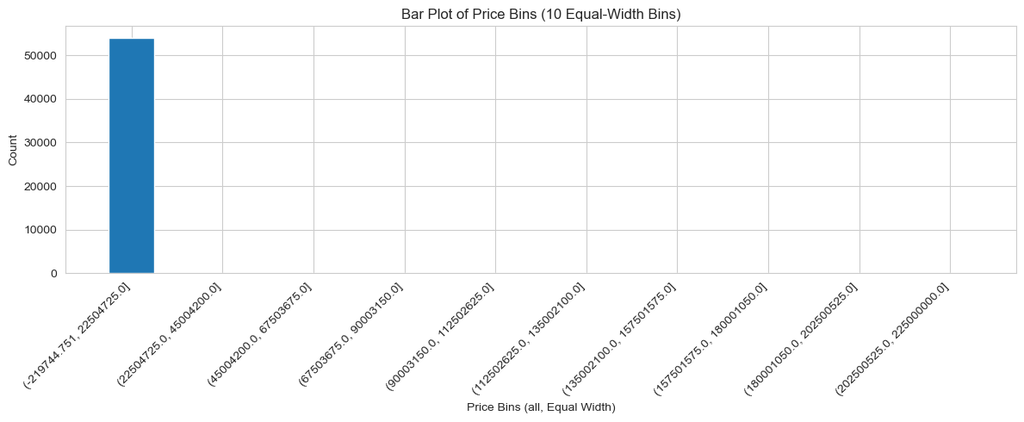

```python
# Price bins on full range (reuse cached price_num)
if 'price_num' not in globals():
```

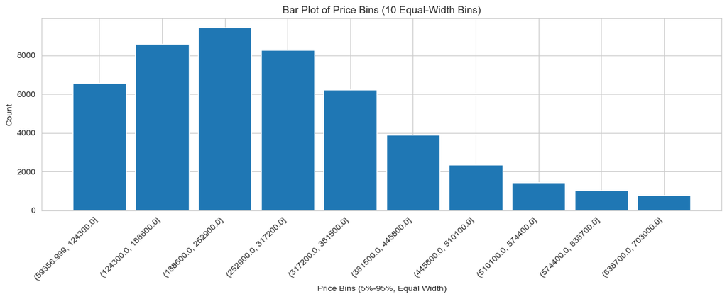

```python
# Price bins on central range (5%-95%) using cached quantiles
if 'price_num' not in globals():
```

## 8) Quick Visual Checks on Price Distribution

Use quick plots (raw/log/box-style) to validate skewness, outliers, and the effect of clamping.

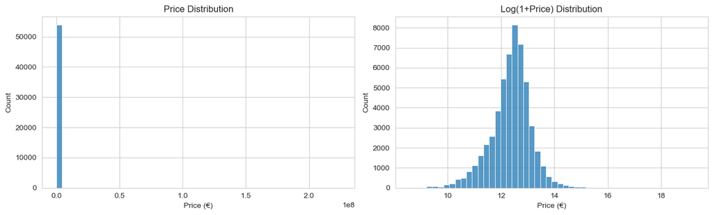

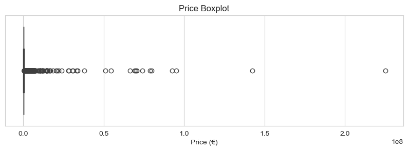

|  | Date of Sale (dd/mm/yyyy) | Address | County | Eircode | Price (€) | Not Full Market Price | VAT Exclusive | Description of Property | Property Size Description | Sale Year | Sale Month |
| --- | --- | --- | --- | --- | --- | --- | --- | --- | --- | --- | --- |
| 46338 | 2023-02-10 | O'Devaney Gardens, Arbour Hill, Dublin 7 | Dublin | NaN | 2.250000e+08 | Yes | Yes | New Dwelling house /Apartment | NaN | 2023 | 2 |
| 20370 | 2019-12-23 | Blocks A and C, The Point Campus | Dublin | NaN | 1.422566e+08 | No | Yes | New Dwelling house /Apartment | NaN | 2019 | 12 |
| 22259 | 2019-05-27 | Apartments 1-164 Fairwary Court, &amp; 1-50 Fa... | Dublin | NaN | 9.524229e+07 | No | Yes | New Dwelling house /Apartment | NaN | 2019 | 5 |
| 46850 | 2023-12-20 | Blocks D1 D2 D3 and D4, Cúil Dúin Avenue, Ci... | Dublin | NaN | 9.251101e+07 | No | Yes | New Dwelling house /Apartment | NaN | 2023 | 12 |
| 49087 | 2024-06-27 | Blocks 5A-5D (including basement), Belmayne Av... | Dublin | NaN | 7.973568e+07 | No | Yes | New Dwelling house /Apartment | NaN | 2024 | 6 |
| 49227 | 2024-02-12 | Barnwell Park, Hansfield | Dublin | NaN | 7.886671e+07 | No | Yes | New Dwelling house /Apartment | NaN | 2024 | 2 |
| 37610 | 2022-10-07 | Apartments 1 - 190, Balroy House, Carpentersto... | Dublin | NaN | 7.407876e+07 | No | Yes | New Dwelling house /Apartment | NaN | 2022 | 10 |
| 48859 | 2024-12-09 | BLOCK B, AIRTON PLAZA, TALLAGHT | Dublin | NaN | 7.037500e+07 | No | Yes | New Dwelling house /Apartment | NaN | 2024 | 12 |
| 17478 | 2018-07-27 | 182 THE ELYSIAN, EGLINTON STREET, CORK | Cork | NaN | 6.987348e+07 | Yes | No | Second-Hand Dwelling house /Apartment | NaN | 2018 | 7 |
| 1716 | 2016-12-19 | Binary Hub Roe's Lane, Bonham Street | Dublin | NaN | 6.920816e+07 | No | No | New Dwelling house /Apartment | greater than or equal to 125 sq metres | 2016 | 12 |
| 12371 | 2018-06-22 | 163 UNITS AT CLANCY QUAY, ISLANDBRIDGE | Dublin | NaN | 6.643172e+07 | Yes | No | Second-Hand Dwelling house /Apartment | NaN | 2018 | 6 |
| 34926 | 2021-09-17 | The Gate Lodge and Rostrevor Place, (comprisin... | Dublin | NaN | 5.458744e+07 | No | No | New Dwelling house /Apartment | NaN | 2021 | 9 |
| 32653 | 2021-12-21 | 36 36 1/2 35 34 33 rear of 33, 32 rear of 32... | Dublin | D08K20T | 5.110579e+07 | No | No | Second-Hand Dwelling house /Apartment | NaN | 2021 | 12 |
| 30101 | 2021-02-04 | Mixed use development, at Swiss Cottage, Santry | Dublin | NaN | 3.809457e+07 | No | Yes | New Dwelling house /Apartment | NaN | 2021 | 2 |
| 12399 | 2018-12-17 | APT1 AND OTHERS, NEW BANCROFT SQUARE, MAIN STREET | Dublin | NaN | 3.392070e+07 | No | No | Second-Hand Dwelling house /Apartment | NaN | 2018 | 12 |
| 4846 | 2016-03-24 | APT 1 THOMOND VILLAGE, UNIVERSITY OF LIMERICK ... | Clare | NaN | 3.318000e+07 | No | No | Second-Hand Dwelling house /Apartment | NaN | 2016 | 3 |
| 37925 | 2022-05-17 | LORETO HALL, ST. STEPHENS GREEN, DUBLIN 2 | Dublin | D02YA47 | 3.100000e+07 | No | No | Second-Hand Dwelling house /Apartment | NaN | 2022 | 5 |
| 31150 | 2021-12-21 | Block B, Santry Place, Swords Road | Dublin | NaN | 3.050817e+07 | No | Yes | New Dwelling house /Apartment | NaN | 2021 | 12 |
| 26109 | 2020-12-10 | 108 FERNWOOD, GLYNNTOWN, GLANMIRE | Cork | NaN | 2.820000e+07 | No | No | Second-Hand Dwelling house /Apartment | NaN | 2020 | 12 |
| 25146 | 2020-10-28 | Block E2, Dublin Landings | Dublin | NaN | 2.819383e+07 | No | Yes | New Dwelling house /Apartment | NaN | 2020 | 10 |

```python
# Price distribution (target)
price_col = 'Price (€)'
```

## 9) Save a Cleaned Preview CSV (Optional)

Export an intermediate cleaned preview file for downstream checks and reproducibility.

```python
# Keep this as a clean- preview output for your own checks
out_file = 'ppr-group-25208508-train-preview.csv'
```

```
Saved: ppr-group-25208508-train-preview.csv
```

## 10) Prepare DQR Report

This section structures report-ready evidence (tables and plots) for DQR summary writing.

## 10.1) Data Validation

Validate schema and feature-level summary statistics used in the report appendix.

```python
# Data validation checks: only duplicate rows/columns
rows, cols = df.shape
```

```
Duplicate rows: 9
Duplicate column pairs: 0
[]
```

## 10.2) Missingness Visualization

Visualize missing-value ratios to support keep/drop/impute decisions.

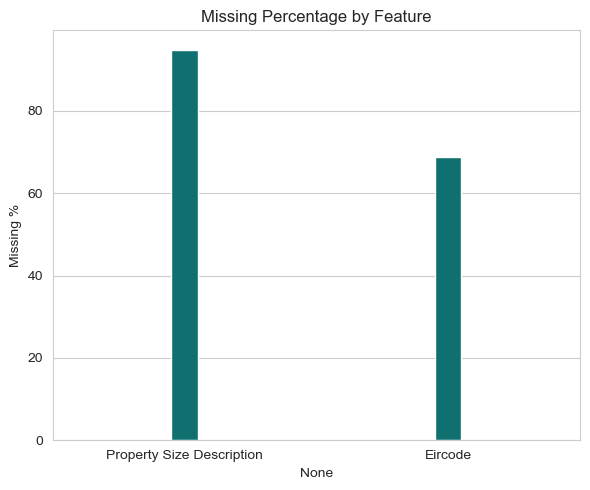

```python
# Missing value percentage bar chart
missing_pct = (df.isna().mean() * 100).sort_values(ascending=False)
```

## 10.3) Categorical Feature Visualization

Inspect distribution imbalance and cardinality for key categorical features.

[figure not shown]

```python
#  category bar plots for selected categorical columns (combined layout)
candidate_cats = [
```

## 10.4) VAT Exclusive = No vs Description of Property

Check interaction between VAT status and property-type categories.

```
Rows with VAT Exclusive = 'No': 44478
```

|  | Description of Property | count | pct_% |
| --- | --- | --- | --- |
| 0 | Second-Hand Dwelling house /Apartment | 44324 | 99.65 |
| 1 | New Dwelling house /Apartment | 151 | 0.34 |
| 2 | Teach/Árasán Cónaithe Atháimhe | 3 | 0.01 |

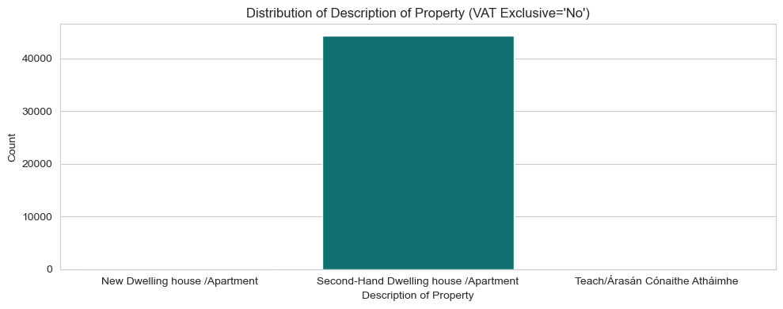

```
Rows not matching expected label 'Second-Hand Dwelling house /Apartment': 154
```

|  | VAT Exclusive | Description of Property |
| --- | --- | --- |
| 167 | No | New Dwelling house /Apartment |
| 316 | No | New Dwelling house /Apartment |
| 1182 | No | New Dwelling house /Apartment |
| 1615 | No | New Dwelling house /Apartment |
| 1716 | No | New Dwelling house /Apartment |
| 1862 | No | New Dwelling house /Apartment |
| 2047 | No | New Dwelling house /Apartment |
| 2305 | No | New Dwelling house /Apartment |
| 2502 | No | New Dwelling house /Apartment |
| 2739 | No | New Dwelling house /Apartment |
| 3734 | No | New Dwelling house /Apartment |
| 4389 | No | New Dwelling house /Apartment |
| 4532 | No | New Dwelling house /Apartment |
| 5591 | No | New Dwelling house /Apartment |
| 5752 | No | New Dwelling house /Apartment |
| 5937 | No | New Dwelling house /Apartment |
| 6740 | No | New Dwelling house /Apartment |
| 6828 | No | New Dwelling house /Apartment |
| 6948 | No | New Dwelling house /Apartment |
| 7046 | No | New Dwelling house /Apartment |

```python
# Analyze Description of Property distribution when VAT Exclusive == 'No'
required_cols = ['VAT Exclusive', 'Description of Property']
```

## 10.5) Numerical Feature Visualization

Visualize numerical behavior (dispersion, skewness, trend cues) for report interpretation.

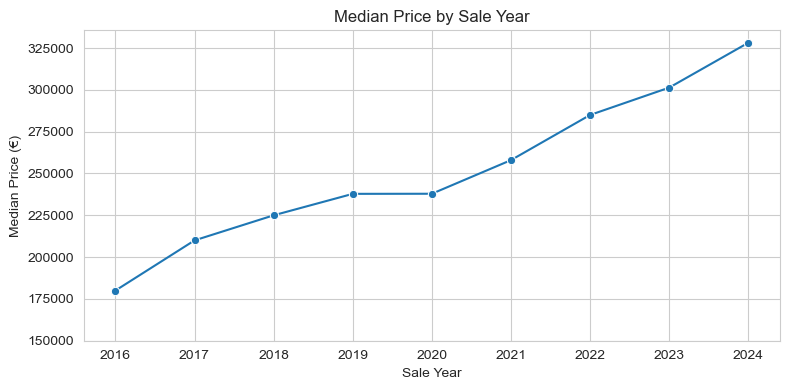

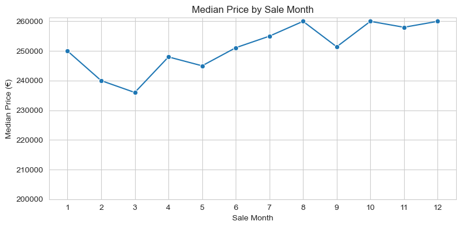

```python
# Median price trend by Sale Year and Sale Month
if {'Price (€)', 'Sale Year'}.issubset(df.columns):
```

## 10.7) Price by County Boxplot

Compare county-level price distributions and identify location-driven heterogeneity.

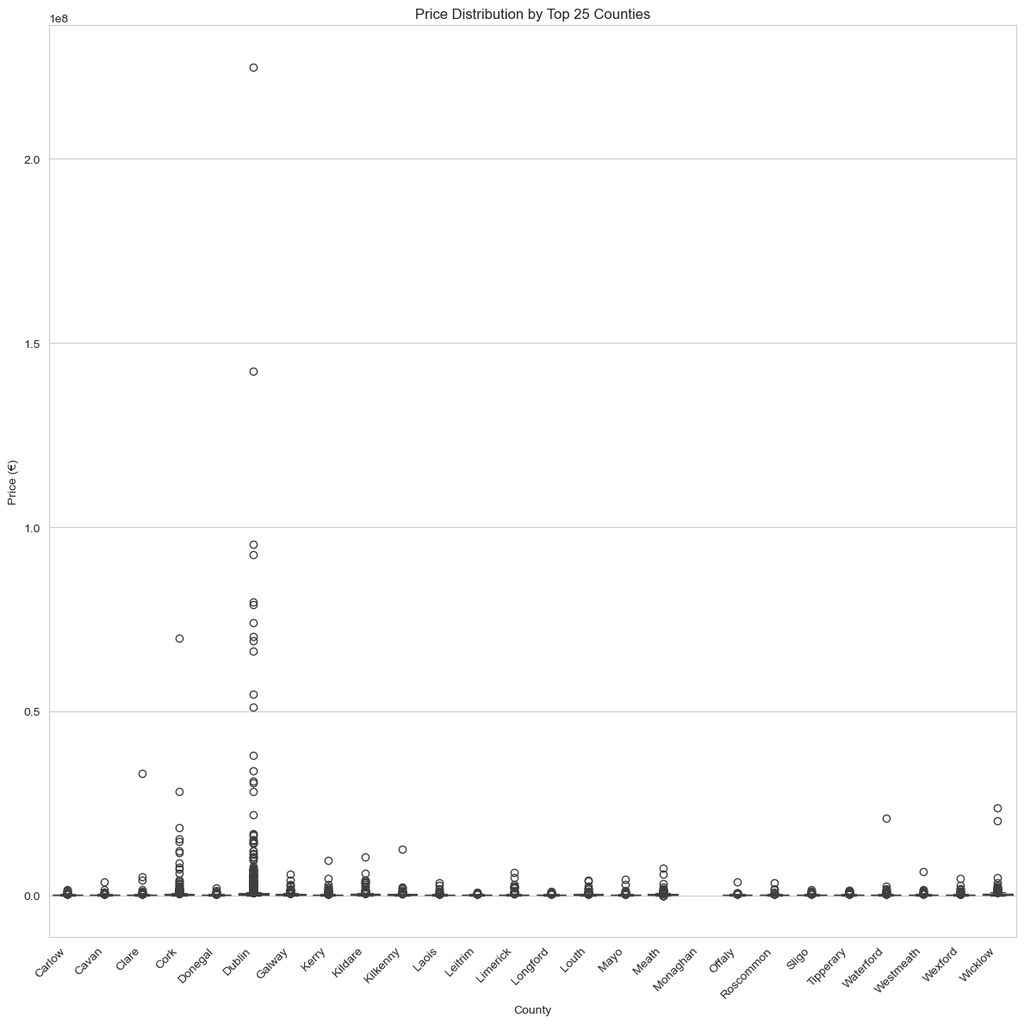

```python
if {'Price (€)', 'County'}.issubset(df.columns):
```

## 10.8) Comprehensive Summary and Export

```python
# Save DQR tables to CSV
numeric_out = 'PropertyPrice-DataQualityReport-NumericFeatures-Summary-Table.csv'
```

```
Numeric DQR table is empty, not saved.
Categorical DQR table is empty, not saved.
```

## 10.8.1) Row/Column Removal Decision Log (Template)

Template table for documenting removal decisions with rationale and impact.

```python
import pandas as pd
from IPython.display import Markdown, display
```

[output not shown]

## 10.9) Data Quality Plan Preparation

Draft issue-to-action mapping to feed the DQP stage.

```python
# Build a draft Data Quality Plan
feature_types = df.dtypes.astype(str)
```

|  | Feature | Feature Type | Data Quality Issue | Handling Strategy |
| --- | --- | --- | --- | --- |
| 0 | Date of Sale (dd/mm/yyyy) | datetime64[us] | No major issue detected | Retain feature as derived from Date of Sale |
| 1 | Address | str | High-cardinality text/location feature | Extract compact zone number, then drop raw high-cardinality field |
| 2 | County | category | No major issue detected | Retain feature as derived from Date of Sale |
| 3 | Eircode | str | High missing values (68.7%) High-cardinality text/location feature | Assess business relevance; drop feature if non-critical, otherwise apply engineer Extract compact zone number, then drop raw high-cardinality field |
| 4 | Price (€) | float64 | Potential skewness and high-end outliers | Use log1p(Price) for modeling; apply percentile capping only when justified |
| 5 | Not Full Market Price | category | No major issue detected | Retain feature as derived from Date of Sale |
| 6 | VAT Exclusive | category | Only for Description of Property == 'New Dwelling house /Apartment', VAT Exclusive=Yes implies +13.5% VAT adjustment | For New Dwelling house /Apartment with VAT Exclusive=Yes, create VAT-adjusted feature: Price * 1.135 |
| 7 | Description of Property | category | No major issue detected | Retain feature as derived from Date of Sale |
| 8 | Property Size Description | category | High missing values (94.7%) | Assess business relevance; drop feature if non-critical, otherwise apply engineer |
| 9 | Sale Year | category | No major issue detected | Retain feature as derived from Date of Sale |
| 10 | Sale Month | category | No major issue detected | Retain feature as derived from Date of Sale |

```
Saved: PropertyPrice-DataQualityPlan-Draft.csv
```